# act_report

## Report: Act Report

@WeRateDogs is a famous twitter page popularly known for humorously rating all kinds of dogs. Below is a picture shows the rating of a cute dog named as "Forrest"

[figure not shown]

This report is concentrated on the analysis and insights that were made after going through the relevant data wrangling process. Only three(3) analysis, but one data visualization were made in this section of the project.

First, in our first analysis we tried looking at the part of the day were 'WeRateDogs' got more interactions on an average. We begin by extracting the hours from each time column in the dateset using dt.hour function. To divide the day into parts we use the pandas cut function, then created a range of 6 hours for each parts of the day together with their respective labels to match each range of hours and assigned it a new column named "parts_of_day". Now to figure out the parts of day where @WeRateDogs gain the most average twitter interactions, we grouped the dataset by 'parts_of_day' column and compute the average favorite_count(likes) on each part of the day. From this analysis, we found out that parts of the day were @WeRatesDogs get more average likes is from morning to midday(06:00-11:59). This shows that people are more likely to engage in a post during early hours of the day. It's also a sign people are more active during this part of the day.

Second, in our second analysis we tried looking that sources from which this interactions come from. By virtue of this, we grouped the dataset by the 'source' column and compute the sum of 'tweets_ounts' and 'favorite_count' made based on each source. We found that 'Twitter for iPhone' was the source from which @WeRateDogs audience interact their post the most. It only shows that most of the post are likely to come from non other than an iPhone user.

Third, we tried looking at the stages in a dog's life cycle with regards to the ratings associated with each on an average. To arrive at a valuable insight, we grouped the dataset by each stage in a dogs life cycle and compute it by the average rating numerator. We found that dog's with highest average rating are doggo's and pupper's. This only shows that dogs at doggo and pupper stage happen to be the most admirable according to @WeRateDogs ratings on an average.

##### "Harry just saw himself in @Weratedogs's calendar!!!!

##### 13/10 would model again 🏍😎" read the post

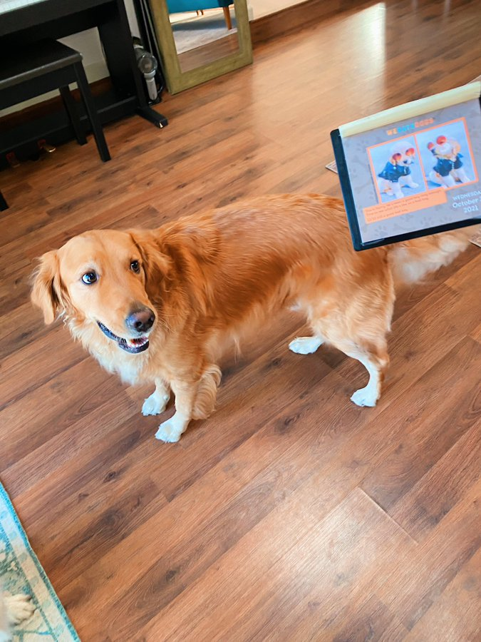

Fourth, the library used for the visualization is matplotlib.pyplot. The visualization is about the parts of the day where @WeRateDog's got more twitter interaction. The visualization was made in a form of a bar chart, with 'Part of the Day' as it's x-axis, 'Number of likes' on the y-axis and a title 'Twitter Interaction By Parts of the Day @WeRateDogs.

Below is the visualization of @WeRateDog's twitter interaction by the day.

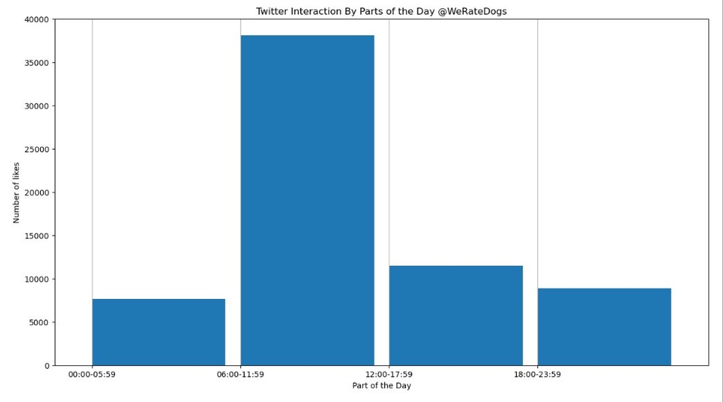

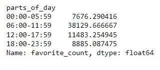